# Parallel Tempering as an Identification Diagnostic for Bayesian DSGE Models

Proof of Concept — the FS2000 Baseline

Author

Emad Saberi

Published

May 23, 2026

Abstract

This document presents a working proof of concept for using parallel tempering (PT) — specifically the modern PT diagnostics exposed by Pigeons.jl — as a Bayesian counterpart to existing analytical identification tests for DSGE models. We replicate the well-known Schorfheide (2000) FS2000 monetary model in Julia (MacroModelling.jl + Turing.jl + Pigeons.jl), compare NUTS and PT posterior estimates, and read the global and local communication barriers as quantitative summaries of identification quality. FS2000 serves as the *well-identified baseline* against which weakly- or partially-identified specifications will be compared in subsequent work.

# Background

## What is a DSGE model?

Dynamic Stochastic General Equilibrium (DSGE) models represent macroeconomies as systems of equations derived from microfounded optimization problems: households maximizing intertemporal utility, firms maximizing profits, markets clearing in equilibrium, a central bank setting policy. The resulting non-linear equilibrium conditions are typically:

1. **Solved for the deterministic steady state** — the equilibrium that prevails when all stochastic shocks are zero.
2. **Log-linearized** around that steady state to obtain a linear system of rational-expectations equations.
3. **Cast in state-space form** $s_t = \Phi_1(\theta)\,s_{t-1} + \Phi_\epsilon(\theta)\,\epsilon_t$, $y_t = \Psi_0(\theta) + \Psi_1(\theta)\,s_t$, enabling likelihood evaluation via the Kalman filter.
4. **Estimated by Bayesian methods**: priors on the structural parameters $\theta$ — preferences, technology, policy rule coefficients, shock standard deviations — are combined with the likelihood through MCMC, historically random-walk Metropolis–Hastings and more recently Hamiltonian variants such as the No-U-Turn Sampler.

DSGE models are central to monetary policy analysis at major central banks and are used for forecasting, counterfactual policy analysis, and the structural decomposition of business-cycle fluctuations. Textbook treatments include Herbst and Schorfheide (2016) and An and Schorfheide (2007).

## Identification problems in DSGE estimation

Canova and Sala (2009) identify three distinct identification pathologies that pervade medium- and large-scale DSGE models:

1. **Observational equivalence (under-identification).** Different parameter vectors $\theta_1 \neq \theta_2$ generate identical likelihoods $p(y \mid \theta_1) = p(y \mid \theta_2)$. The structural-parameters-to-observable-moments mapping is many-to-one, and no amount of additional data can distinguish $\theta_1$ from $\theta_2$.
2. **Partial identification.** Only certain functions or combinations of parameters are pinned down by the data. The likelihood is informative in some directions of $\theta$-space and flat in others.
3. **Weak identification.** Identification is technically present but poorly informed by the data — the likelihood has nearly-flat ridges, and small perturbations in the data produce disproportionately large changes in parameter estimates.

These problems are not edge cases: as DSGE models add propagation mechanisms and shocks to better match the data, the parameter space expands faster than the information content of typical macro samples (quarterly observations over a few decades).

## How identification is currently checked in practice

Three families of techniques are common.

- **Pre-estimation analytical tests.** Iskrev (2010): rank conditions on the Jacobian of the model-implied moment mapping; Komunjer and Ng (2011) provide spectral-density-based tests; Canova and Sala (2009) themselves develop local sensitivity diagnostics. These tools are powerful but local-linear, Gaussian-asymptotic, and silent about non-local pathologies like multimodality.
- **Post-estimation informal checks.** Comparing prior-to-posterior moments and shapes (a posterior that closely tracks the prior signals weak identification); running multiple chains from different starting points and inspecting consistency; visually examining bivariate posterior plots for ridges.
- **Robustness checks.** Reporting estimates under alternative prior specifications and data subsamples.

Each approach has its limitation. Analytical tests assume a regularity environment, and DSGE posteriors may not satisfy them. Informal checks don’t have quantitative summaries that travel across models. Multiple-chain starting-point checks mix up identification problems with ordinary sampler convergence issues.

## Parallel tempering and Pigeons.jl

Parallel tempering (PT; originally Geyer (1991)) constructs a sequence of tempered distributions interpolating between a measurable reference and the target posterior:

$$\pi_\beta(\theta) \;\propto\; \pi_{\text{ref}}(\theta)^{1-\beta}\,\pi_{\text{target}}(\theta)^{\beta}, \quad \beta \in [0,1].$$

$N$ MCMC chains target $\pi_{\beta_0}, \pi_{\beta_1}, \ldots, \pi_{\beta_N}$ at grid points of a temperature schedule with $0 = \beta_0 < \beta_1 < \cdots < \beta_N = 1$. The reference chain ($\beta=0$) is by construction easy to sample (prior here) and the target chain ($\beta=N$) is the posterior of interest. Adjacent chains exchange states from Metropolis-style swap moves, allowing the posterior chain to inherit broad exploration from the prior chain.

Pigeons.jl (Surjanovic et al. 2025) implements modern PT with diagnostics drawn from Syed et al. (2022). Three quantities are central:

- **Global communication barrier** $\Lambda$: an information-theoretic scalar measuring the total mixing difficulty along the prior-to-posterior path. $\Lambda$ measures, broadly, the number of chains required for efficient sampling — the rule of thumb is $N \approx 2\Lambda$ — and the expected restart rate scales as $\approx 1/(2 + 2\Lambda + \Lambda^2)$.
- **Local communication barrier** $\lambda(\beta)$: shows *where* along the tempered path the mixing difficulty is concentrated, satisfying $\Lambda = \int_0^1 \lambda(\beta)\,d\beta$. Peaks near $\beta = 0$ indicate prior-posterior mismatch — the data are highly informative relative to the prior. Peaks near $\beta = 1$ indicate issues within the posterior itself — likelihood ridges, modal separation, weakly identified directions.
- **Round-trip rate**: how often a replica successfully travels from $\beta = 0$ to $\beta = 1$ and back. Each round trip is functionally an independent draw from the posterior.

Brault (2024), at the Bank of Canada, was the first to apply PT to DSGE estimation, using a MATLAB+Dynare implementation focused on multimodal posteriors. His underlying DSGE model was from Smets-Wouters under diffuse priors (Smets and Wouters 2007; Herbst and Schorfheide 2014). The present work extends that line in two directions: a Julia implementation native to the modern probabilistic-programming ecosystem, and explicit use of the modern barrier diagnostics as **identification** tools rather than as sampler-quality measures.

# Proof of Concept: FS2000

The Schorfheide (2000) FS2000 model is a small monetary DSGE with nine structural parameters and two observable series (output growth and inflation). It is well-identified, has a unique determinate equilibrium across the reasonable region of its parameter space, and has been used as a reference benchmark in the DSGE estimation literature for two decades. It is a natural baseline: we expect the barrier diagnostics to indicate a clean posterior.

## Loading data, model, and priors

All of the model definition, parameter calibration, prior specification, observable data, and Turing/Pigeons plumbing live in a single setup file, `utils/FS2000_PT_setup.jl`. Will discuss why everything is consolidated there in a moment (Child Processes), but for now simply load it.

```julia
# %% Version info
cd(expanduser("~/.julia/dev/MMTP"))
run(`julia --version`)

using Pkg
Pkg.activate(".")
Pkg.instantiate()
Pkg.resolve()
Pkg.status()
```

```
julia version 1.12.6
  Activating project at `~/.julia/dev/MMTP`
     Project No packages added to or removed from `~/.julia/dev/MMTP/Project.toml`
    Manifest No packages added to or removed from `~/.julia/dev/MMTP/Manifest.toml`
Project MMTP v0.1.0
Status `~/.julia/dev/MMTP/Project.toml`
  [94b1ba4f] AxisKeys v0.2.17
  [6e4b80f9] BenchmarkTools v1.8.0
  [336ed68f] CSV v0.10.16
⌃ [992eb4ea] CondaPkg v0.2.33
  [a93c6f00] DataFrames v1.8.2
⌅ [366bfd00] DynamicPPL v0.35.9
⌅ [a98d9a8b] Interpolations v0.15.1
  [2b0e0bc5] LanguageServer v5.0.0
⌅ [c7f686f2] MCMCChains v6.0.7
  [687ffad2] MacroModelling v0.1.46
⌃ [0eb8d820] Pigeons v0.4.10
⌅ [08abe8d2] PrettyTables v2.4.0
  [295af30f] Revise v3.14.3
  [f3b207a7] StatsPlots v0.15.8
⌃ [fce5fe82] Turing v0.37.0
  [37e2e46d] LinearAlgebra v1.12.0
  [9e88b42a] Serialization v1.11.0
Info Packages marked with ⌃ and ⌅ have new versions available. Those with ⌃ may be upgradable, but those with ⌅ are restricted by compatibility constraints from upgrading. To see why use `status --outdated`
```

```julia
# %% Imports
import CondaPkg
import Serialization: serialize, deserialize
import Turing
import Turing: NUTS
import MacroModelling as MM
import StatsPlots: plot, savefig
import Pigeons
import MCMCChains as MCMCC
import PrettyTables: pretty_table

CondaPkg.resolve()
include("utils/utils.jl")
include("utils/FS2000_PT_setup.jl")
```

```
Observables: [:log_gp_obs, :log_gy_obs]
Number of parameters: 9
```

## A NUTS baseline

Before reaching for parallel tempering, we run NUTS (Turing.jl’s default Hamiltonian sampler) as a single-chain reference. If PT does its job, the marginal posteriors from NUTS and PT should agree closely.

```julia
sample_method = NUTS()
NUTS_n_samples = 1000

FS2000_NUTS_chain = cache_or_compute("assets/cache/FS2000_NUTS_chain.jls") do
    Turing.sample(FS2000_loglik_pop,
        sample_method,
        NUTS_n_samples,
        initial_params=FS2000.parameter_values)
end

paramlist = MM.get_parameters(FS2000)
rename_map = Dict("parameters[$i]" => string(p) for (i, p) in enumerate(paramlist))

FS2000_NUTS_chain_renamed = MCMCC.replacenames(FS2000_NUTS_chain, rename_map)

MCMCC.summarize(FS2000_NUTS_chain_renamed)
```

```
[ Info: Loading cached result from assets/cache/FS2000_NUTS_chain.jls
```

```
  parameters      mean       std      mcse    ess_bulk   ess_tail      rhat   ess_per_sec
      Symbol   Float64   Float64   Float64     Float64    Float64   Float64       Float64

           α    0.4026    0.0213    0.0009    558.7371   679.3682    1.0013        1.2390
           β    0.9904    0.0022    0.0001    744.6278   738.9525    0.9997        1.6512
           γ    0.0046    0.0010    0.0000   1026.5604   699.6500    1.0005        2.2763
         mst    1.0142    0.0017    0.0001   1064.7269   718.9306    0.9990        2.3610
           ρ    0.8452    0.0348    0.0012    794.4187   598.5900    1.0027        1.7616
           ψ    0.6843    0.0508    0.0015   1190.8159   784.1843    0.9994        2.6406
           δ    0.0025    0.0013    0.0000    792.5587   550.3049    1.0018        1.7574
       z_e_a    0.0137    0.0009    0.0000    464.1907   692.1887    1.0020        1.0293
       z_e_m    0.0033    0.0002    0.0000    683.0508   678.9875    1.0013        1.5146
```

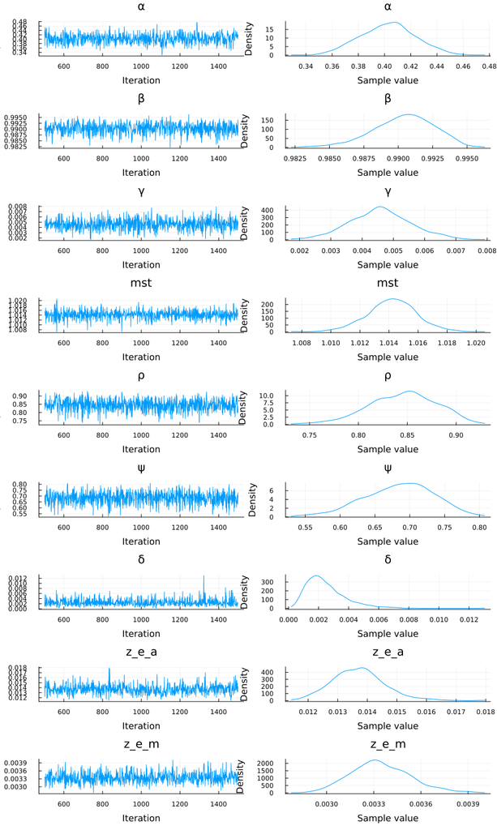

NUTS trace and posterior density plots for FS2000.

```julia
plot(FS2000_NUTS_chain_renamed; size = (900, 1500))
```

The NUTS run completes cleanly in a few minutes on a single thread, with no divergence warnings and a roughly Gaussian posterior shape that closely tracks the published estimates for FS2000 in the literature. Nice.

## Why the setup is split into its own file

Parallel tempering can be run single-process with `multithreaded = false`, but for any non-trivial number of rounds the real time cost is steep. Pigeons.jl supports MPI-based multi-process parallelism through `ChildProcess`, in which each MCMC replica runs in its own Julia process. Two facts make this the right architecture for MacroModelling-based targets:

1. **Within a single Julia process, MacroModelling’s internal caches are not thread-safe.** Two threads calling `get_loglikelihood` concurrently corrupt each other’s state. This is why we run with `multithreaded = false`.
2. **Across separate processes, the model object is naturally per-process.** Each child Julia process loads its own copy of MacroModelling and constructs its own `FS2000` model object, so there is no shared mutable state to corrupt. Parallelism is safe at the process level even when it is not safe at the thread level.

The drawback is that each child process must be able to *re-create* the full target distribution — model, priors, Turing wrapper, custom `Pigeons.initialization` method — from scratch on launch. Pigeons.jl handles this by `include`-ing a setup file in every child. That setup file must therefore be self-contained: every `import` and `using` it needs has to be at the top of the file, not in the parent script that opened the REPL. Putting the FS2000 setup in `utils/FS2000_PT_setup.jl` and using only that path as a dependency is pretty clean.

## The Pigeons sampling call

```julia
const PIGEONS_SEED = 123

FS2000_PT = pt_cache_or_compute("assets/cache/FS2000_PT_chain") do
    Pigeons.pigeons(
        target=FS2000_PT_lp, #stands for FS2000_PT log potential, defined within FS2000_PT_setup.jl
        record=[
            Pigeons.traces;
            Pigeons.round_trip;
            Pigeons.record_default()
        ],
        n_chains=10,
        n_rounds=8,
        seed=PIGEONS_SEED,
        checkpoint=true,
        on=Pigeons.ChildProcess(
            n_local_mpi_processes=4,
            n_threads=1,
            dependencies=[abspath("utils/FS2000_PT_setup.jl")]
        )
    )
end
```

```
[ Info: Loading cached PT from assets/cache/FS2000_PT_chain
```

```
PT("/home/emad/.julia/dev/MMTP/results/all/2026-05-23-20-48-09-xwXtcghr")
```

## Loading the cached PT result

```julia
FS2000_PT_chain = MCMCC.Chains(FS2000_PT)
FS2000_PT_chain_renamed = MCMCC.replacenames(FS2000_PT_chain, rename_map)
MCMCC.summarize(FS2000_PT_chain_renamed)
```

```
  parameters      mean       std      mcse   ess_bulk   ess_tail      rhat   ess_per_sec
      Symbol   Float64   Float64   Float64    Float64    Float64   Float64       Missing

           α    0.4027    0.0203    0.0015   182.8458   184.3188    1.0036       missing
           β    0.9902    0.0021    0.0002   188.6486   210.5632    0.9974       missing
           γ    0.0045    0.0010    0.0001   159.2525   192.5253    0.9968       missing
         mst    1.0141    0.0017    0.0001   184.2040   236.9553    0.9989       missing
           ρ    0.8465    0.0347    0.0022   240.8702   242.9075    1.0131       missing
           ψ    0.6832    0.0447    0.0028   267.0371   224.2834    1.0009       missing
           δ    0.0025    0.0014    0.0001   233.7673   213.1303    1.0077       missing
       z_e_a    0.0137    0.0009    0.0001   177.9443   242.8449    0.9984       missing
       z_e_m    0.0033    0.0002    0.0000   243.5669   246.3629    0.9990       missing
```

## Posterior comparison

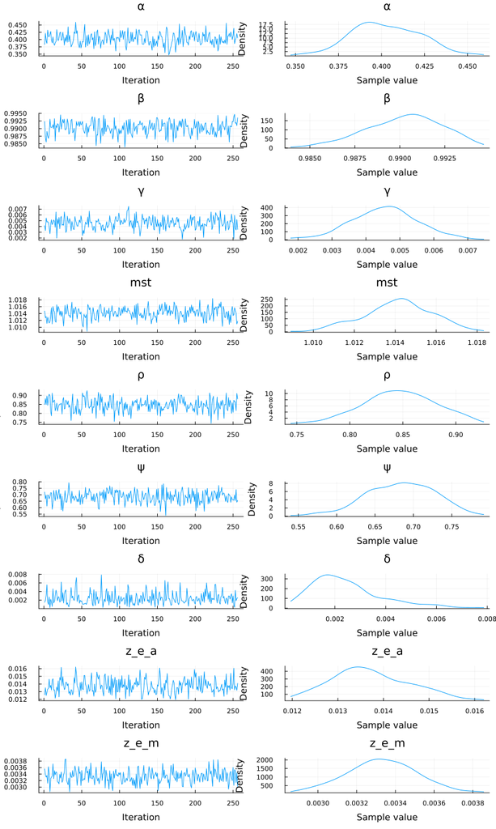

Parallel-tempering posterior marginals for FS2000.

```julia
plot(FS2000_PT_chain_renamed; size = (900, 1500))
```

The NUTS and PT marginal posteriors agree closely on means and credible intervals across all nine parameters. That agreement is exactly what’s expected from a well-identified baseline: two qualitatively different samplers landing on the same posterior characterization. Disagreement at this stage would signal either a sampling pathology or a posterior shape that neither sampler is fully resolving.

## Communication barriers

### Reading the PT machinery table

As Pigeons runs parallel sampling scans, the following table populates:

```julia
# %%
pretty_table(pigeons_summary;
    backend=Val(:html),
    show_subheader=false)
```

| round | scans | restarts | Λ | time(s) | alloc(B) | log(Z₁/Z₀) |
| --- | --- | --- | --- | --- | --- | --- |
| 1 | 2 | 0 | 5.64525 | 14.789 | 1.1724e9 | 1227.57 |
| 2 | 4 | 0 | 2.27424 | 24.4443 | 2.27926e9 | 1288.58 |
| 3 | 8 | 0 | 4.3811 | 43.7951 | 4.28038e9 | 1300.22 |
| 4 | 16 | 0 | 5.44465 | 89.4452 | 8.60888e9 | 1301.07 |
| 5 | 32 | 0 | 4.97679 | 142.595 | 1.35245e10 | 1300.42 |
| 6 | 64 | 1 | 4.87108 | 265.603 | 2.68164e10 | 1300.16 |
| 7 | 128 | 2 | 5.23478 | 439.503 | 4.42192e10 | 1299.78 |
| 8 | 256 | 12 | 5.23779 | 616.134 | 6.50848e10 | 1300.11 |

To read this table:

1. Each row indicates a new tuning round in parallel tempering.
2. **scans** indicate the number of samples from that tuning round.
3. **restarts** indicate the number of samples form the reference (prior?) which successfully percolate to the target (posterior?) distribution. In this example, with `n_rounds=8`, we see 12 tempered restarts. The number of restarts is expected to greatly increase for later rounds. For a production-quality run, we would set `n_rounds=10+`. A higher number indicates more successful mixing and is more desirable.
4. **$\Lambda$** indicates the global communication barrier described earlier. The inherent difficulty of the sampling problem. Used in the rule of thumb calculation for the number of chains to be running the parallel tempering engine on.
5. **log(Z_1/Z_0)** indicates the “stepping stone estimator” of the paralllel tempering output.

### Interpreting Global/Local Communication Barriers

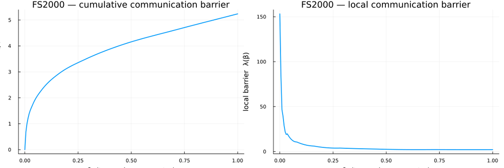

```julia
using Interpolations

# Extract the underlying interpolation object
localbar = FS2000_PT.shared.tempering.communication_barriers.localbarrier
itp = getfield(localbar, first(fieldnames(typeof(localbar))))

# Sample on a dense β-grid for smooth plotting
βs                    = range(0, 1, length = 200)
cum_barrier           = itp.(βs)
local_barrier_density = [Interpolations.gradient(itp, β)[1] for β in βs]

p1 = plot(βs, cum_barrier;
          xlabel = "β  (tempering parameter)",
          ylabel = "cumulative barrier  Λ(β)",
          title  = "FS2000 — cumulative communication barrier",
          legend = false, lw = 2)

p2 = plot(βs, local_barrier_density;
          xlabel = "β  (tempering parameter)",
          ylabel = "local barrier  λ(β)",
          title  = "FS2000 — local communication barrier",
          legend = false, lw = 2)

plot(p1, p2; layout = (1, 2), size = (1200, 400))
```

```julia
Λ         = Pigeons.global_barrier(FS2000_PT)
restarts  = Pigeons.n_round_trips(FS2000_PT)
```

[output not shown]

## Reading the result: FS2000 is well-identified

# To Come

The proof of concept above establishes the pipeline and the baseline. Three lines of empirical work follow:

## 1. Comparing well- and weakly-identified specifications of the same model

Running PT on the same model with deliberately diffuse priors on parameters thought to be weakly identified. Holding the model fixed and varying only the prior tightness isolates the contribution of the prior to posterior concentration. Hypothesis: under loose priors, the local barrier curve should develop a non-trivial peak at moderate-to-large $\beta$. This indicates the difficulty has migrated from “the prior is far from the posterior” (the FS2000-baseline regime) to “the posterior itself is geometrically corrupt.”

## 2. Cataloguing barrier signatures across identification pathology types

Canova and Sala (2009) distinguish observational equivalence, partial identification, and weak identification, and each is expected to manifest as a distinct barrier shape. A natural empirical extension is to construct (or identify in the literature) a small set of DSGE specifications exhibiting each pathology type and to report the corresponding $\lambda(\beta)$ curves. Multimodal posteriors — for which Brault (2024) provides the canonical examples (NK with indeterminacy, Smets-Wouters with diffuse priors) — are an additional case where modal separation should produce identifiably distinct barrier signatures from the smooth ridge case.

## 3. A diagnostic framework for any DSGE specification

The end goal (ambitious) is an organized recipe for applying these tools to an arbitrary DSGE model. Outline :

1. Estimate the model with both NUTS and PT; compare posterior marginals as a first sanity check.
2. Read $\Lambda$ against the prior-tightness regime; large $\Lambda$ under tight priors is the main warning sign.
3. Plot $\lambda(\beta)$ and classify the shape (peak at $\beta = 0$, peak at $\beta = 1$, multimodal, flat). Each shape suggests a different intervention — re-examine prior choice, re-examine model specification, re-examine data informativeness.
4. Compare with traditional identification tests (Iskrev rank conditions, Komunjer-Ng spectral tests) on the same parameters; PT diagnostics serve as a complementary Bayesian, sampling-based view.
5. Report all of the above in a standardized “identification appendix” alongside the main estimation results — a contribution toward improving the transparency of identification claims in applied DSGE work.

The first item is already pretty feasible with the pipeline established here. The remaining items define the work plan for the thesis. On we go!

# References

An, Sungbae, and Frank Schorfheide. 2007. “Bayesian Analysis of DSGE Models.” *Econometric Reviews* 26 (2–4): 113–72.

Brault, Joshua. 2024. *Parallel Tempering for DSGE Estimation*. Staff Working Paper Nos. 2024-13. Bank of Canada.

Canova, Fabio, and Luca Sala. 2009. “Back to Square One: Identification Issues in DSGE Models.” *Journal of Monetary Economics* 56 (4): 431–49.

Geyer, Charles J. 1991. “Markov Chain Monte Carlo Maximum Likelihood.” *Computing Science and Statistics: Proc. 23rd Symp. Interface*, 156–63.

Herbst, Edward P., and Frank Schorfheide. 2016. *Bayesian Estimation of DSGE Models*. Princeton University Press.

Herbst, Edward, and Frank Schorfheide. 2014. “Sequential Monte Carlo Sampling for DSGE Models.” *Journal of Applied Econometrics* 29 (7): 1073–98.

Iskrev, Nikolay. 2010. “Local Identification in DSGE Models.” *Journal of Monetary Economics* 57 (2): 189–202.

Komunjer, Ivana, and Serena Ng. 2011. “Dynamic Identification of Dynamic Stochastic General Equilibrium Models.” *Econometrica* 79 (6): 1995–2032.

Smets, Frank, and Rafael Wouters. 2007. “Shocks and Frictions in US Business Cycles: A Bayesian DSGE Approach.” *American Economic Review* 97 (3): 586–606.

Surjanovic, Nikola, Miguel Biron-Lattes, Paul Tiede, Saifuddin Syed, Trevor Campbell, and Alexandre Bouchard-Côté. 2025. “Pigeons.jl: Distributed Sampling from Intractable Distributions.” *Journal of Open Source Software*.

Syed, Saifuddin, Alexandre Bouchard-Côté, George Deligiannidis, and Arnaud Doucet. 2022. “Non-Reversible Parallel Tempering: A Scalable Highly Parallel MCMC Scheme.” *Journal of the Royal Statistical Society Series B* 84 (2): 321–50.